# Section B_Rungta_Riddhi_V01107488

```python
import pandas as pd
import numpy as np
import matplotlib.pyplot as plt
from sklearn.metrics import mean_squared_error, mean_absolute_error
from sklearn.preprocessing import MinMaxScaler
from statsmodels.tsa.statespace.sarimax import SARIMAX
from keras.models import Sequential
from keras.layers import Dense, LSTM
import math
```

```python
# Load the data
df = pd.read_excel('CMO-Historical-Data-Monthly.xlsx', sheet_name="Monthly Prices", skiprows=6)

# Rename the first column to "Date"
df.rename(columns={df.columns[0]: 'Date'}, inplace=True)

# Convert the Date column to datetime format
def parse_date(date_str):
    year, month = date_str[:4], date_str[5:7]
    return pd.to_datetime(f'{year}-{month}-01')

df['Date'] = df['Date'].apply(parse_date)

# Display the structure of the dataframe
print(df.info())
```

```
<class 'pandas.core.frame.DataFrame'>
RangeIndex: 774 entries, 0 to 773
Data columns (total 72 columns):
 #   Column         Non-Null Count  Dtype
---  ------         --------------  -----
 0   Date           774 non-null    datetime64[ns]
 1   CRUDE_PETRO    774 non-null    float64
 2   CRUDE_BRENT    774 non-null    float64
 3   CRUDE_DUBAI    774 non-null    float64
 4   CRUDE_WTI      774 non-null    object
 5   COAL_AUS       774 non-null    object
 6   COAL_SAFRICA   774 non-null    object
 7   NGAS_US        774 non-null    float64
 8   NGAS_EUR       774 non-null    float64
 9   NGAS_JP        774 non-null    object
```

[output cut: 65 more lines]

```python
# Get the column numbers for each column
column_numbers = {col: idx for idx, col in enumerate(df.columns)}

# Select relevant columns
commodity = df.iloc[:, [0, 69]]

# Clean column names
commodity.columns = commodity.columns.str.lower().str.replace(' ', '_')

# Display the structure of the commodity dataframe
print(commodity.info())
```

```
<class 'pandas.core.frame.DataFrame'>
RangeIndex: 774 entries, 0 to 773
Data columns (total 2 columns):
 #   Column  Non-Null Count  Dtype
---  ------  --------------  -----
 0   date    774 non-null    datetime64[ns]
 1   gold    774 non-null    float64
dtypes: datetime64[ns](1), float64(1)
memory usage: 12.2 KB
None
```

```python
commodity.head()
```

|  | date | gold |
| --- | --- | --- |
| 0 | 1960-01-01 | 35.27 |
| 1 | 1960-02-01 | 35.27 |
| 2 | 1960-03-01 | 35.27 |
| 3 | 1960-04-01 | 35.27 |
| 4 | 1960-05-01 | 35.27 |

```python
# Save the daily data to a new CSV file
commodity.to_csv('gold_data.csv')
```

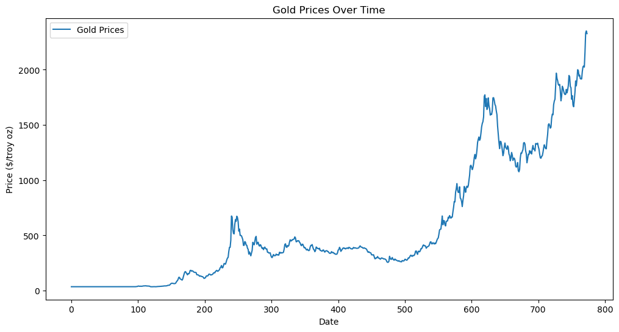

```python
# Plot the data
plt.figure(figsize=(12, 6))
plt.plot(commodity.index, commodity['gold'], label='Gold Prices')
plt.title('Gold Prices Over Time')
plt.xlabel('Date')
plt.ylabel('Price ($/troy oz)')
plt.legend()
plt.show()
```

**At the beginning of the plot, gold prices remain relatively stable and low, indicating a period of little fluctuation. Around the 200-mark, there's a noticeable increase in gold prices, suggesting a significant economic or market event causing this rise. Post the first rise, there are periods of ups and downs, indicating market volatility and possibly reflecting global economic conditions, inflation rates, and investor behavior. Towards the end of the plot, there is a sharp and continuous rise in gold prices, peaking over 2000 per troy ounce. This could be due to recent economic crises, increased demand for gold as a safe-haven asset, or other significant economic events.The plot demonstrates how gold prices have responded to various economic conditions over time. Typically, gold prices increase during economic instability as investors seek safe investments, and the recent surge likely reflects such a period.**

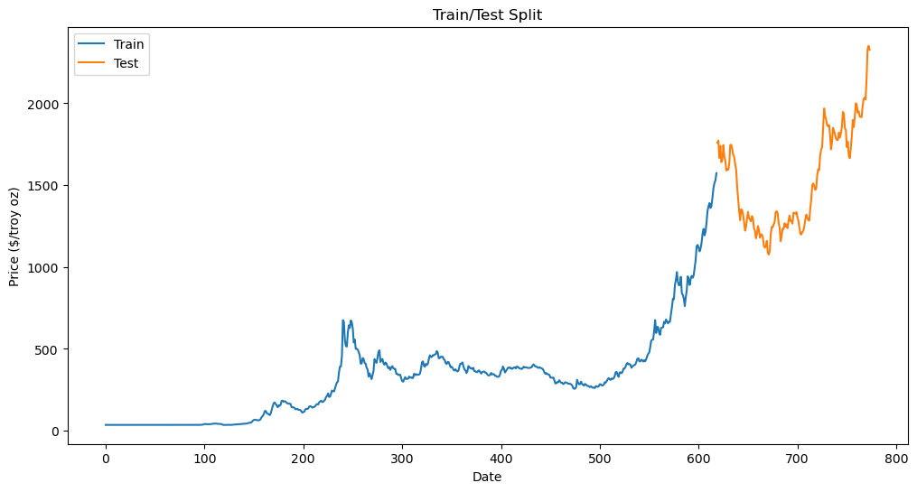

```python
# Assuming a larger dataset, split into train and test sets
train_size = int(len(commodity) * 0.8)
train, test = commodity[:train_size], commodity[train_size:]

# Plot the train and test sets
plt.figure(figsize=(12, 6))
plt.plot(train.index, train['gold'], label='Train')
plt.plot(test.index, test['gold'], label='Test')
plt.title('Train/Test Split')
plt.xlabel('Date')
plt.ylabel('Price ($/troy oz)')
plt.legend()
plt.show()
```

**Both the training and testing datasets highlight an initial period of stability followed by a significant increase in prices, reflecting historical market behavior. The data shows periods of volatility with fluctuations in prices, indicating market responses to various economic factors. Recent Surge: The testing dataset, in particular, shows a sharp recent surge in gold prices, which may be due to contemporary economic conditions, increased demand for gold as a safe-haven asset, or other global financial events.**

**Importance for Model Training: The training data provides a comprehensive view of historical gold prices, essential for training robust predictive models. The testing data offers a segment of recent price movements to validate the model's predictive accuracy and generalizability. By splitting the data this way, one can assess how well a forecasting model can predict future prices based on past trends, ensuring the model is reliable for real-world applications.**

## SARIMA Model

```
SARIMA RMSE: 375.31
SARIMA MAE: 308.75
SARIMA MAPE: 23.38%
```

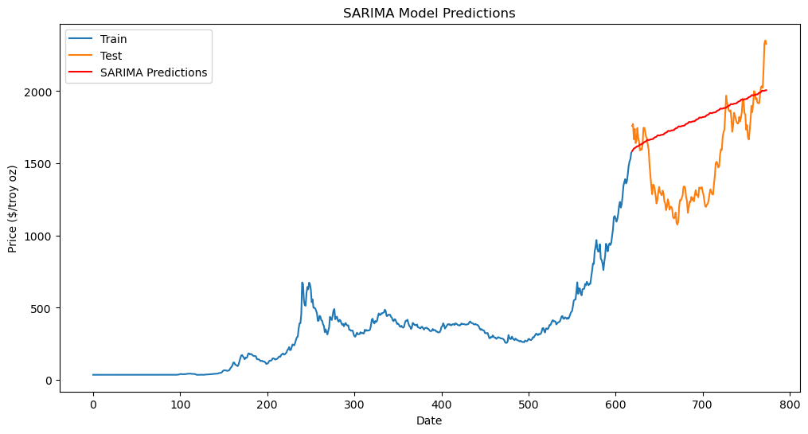

```python
from statsmodels.tsa.statespace.sarimax import SARIMAX
from sklearn.metrics import mean_squared_error, mean_absolute_error
import numpy as np

# Fit SARIMA model (adjust orders as needed)
sarima_model = SARIMAX(train['gold'], order=(1, 1, 1), seasonal_order=(1, 1, 1, 12))
sarima_fit = sarima_model.fit(disp=False)

# Make predictions
sarima_pred = sarima_fit.forecast(steps=len(test))

# Evaluate SARIMA model
sarima_rmse = np.sqrt(mean_squared_error(test['gold'], sarima_pred))
sarima_mae = mean_absolute_error(test['gold'], sarima_pred)
sarima_mape = np.mean(np.abs((test['gold'] - sarima_pred) / test['gold'])) * 100

print(f"SARIMA RMSE: {sarima_rmse:.2f}")
print(f"SARIMA MAE: {sarima_mae:.2f}")
print(f"SARIMA MAPE: {sarima_mape:.2f}%")

# Plot SARIMA predictions
plt.figure(figsize=(12, 6))
plt.plot(train.index, train['gold'], label='Train')
plt.plot(test.index, test['gold'], label='Test')
plt.plot(test.index, sarima_pred, label='SARIMA Predictions', color='r')
plt.title('SARIMA Model Predictions')
plt.xlabel('Date')
plt.ylabel('Price ($/troy oz)')
plt.legend()
plt.show()
```

**The plot illustrates the historical gold prices over time, split into training and testing datasets, along with predictions from a SARIMA model. The blue line represents the training data, capturing historical price movements up to a certain point. The orange line shows the testing data, which includes recent price trends and is used to evaluate the model's performance. The red line represents the SARIMA model's predictions for the test period.**

**The SARIMA model's predictions are compared against the actual test data, and the model's performance is quantified using three metrics: RMSE, MAE, and MAPE. The Root Mean Squared Error (RMSE) of 375.31 indicates the average magnitude of prediction errors, showing that the model's predictions deviate from actual values by this amount on average. The Mean Absolute Error (MAE) of 308.75 further underscores the average prediction error. The Mean Absolute Percentage Error (MAPE) of 23.38% reveals that the model's predictions, on average, deviate from the actual values by approximately 23.38%.**

**The SARIMA model captures the overall trend of increasing gold prices, but there are discrepancies between predicted and actual values, especially during periods of significant price changes. This indicates the model's limitations in capturing short-term volatility and rapid market shifts. However, the model provides a reasonable forecast for the general direction of gold prices, highlighting the importance of considering both trend and variability in financial time series forecasting.**

## LSTM Model

```python
import numpy as np
import matplotlib.pyplot as plt
import math
import pandas as pd
from keras.models import Sequential
from keras.layers import Dense,Input
from keras.layers import LSTM, Flatten
from sklearn.preprocessing import MinMaxScaler
from sklearn.metrics import mean_squared_error
```

```python
# Convert the 'Date' column to datetime format and set it as the index
commodity['date'] = pd.to_datetime(commodity['date'])
commodity.set_index('date', inplace=True)
```

```python
df2 = commodity.values
df2 = df2.astype('float32')
```

```python
##LSTM uses sigmoid and tanh functions that are sensitive to magnitude
##normalize the dataset
scaler = MinMaxScaler(feature_range=(0, 1))
dataset = scaler.fit_transform(df2)
```

```python
train_size = int(len(dataset) * 0.70)
test_size = len(dataset) - train_size
train, test = dataset[0:train_size,:], dataset[train_size:len(dataset),:]
len(train),len(test)
```

```
(541, 233)
```

```python
def to_sequences(dataset, seq_size=1):
    x = []
    y = []

    for i in range(len(dataset)-seq_size-1):
        #print(i)
        window = dataset[i:(i+seq_size), 0]
        x.append(window)
        y.append(dataset[i+seq_size, 0])

    return np.array(x),np.array(y)
```

```python
seq_size = 5
trainX, trainY = to_sequences(train, seq_size)
testX, testY = to_sequences(test, seq_size)
```

```python
trainX = np.reshape(trainX, (trainX.shape[0], 1, trainX.shape[1]))
testX = np.reshape(testX, (testX.shape[0], 1, testX.shape[1]))
```

```python
print('Single LSTM with hidden Dense...')
from keras.callbacks import ModelCheckpoint, EarlyStopping
model = Sequential()
# Add Input layer to define the input shape
model.add(Input(shape=(None, seq_size)))
# Add the LSTM layer
model.add(LSTM(64))
# Add Dense layers
model.add(Dense(32))
model.add(Dense(1))
# Compile the model
model.compile(loss='mean_squared_error', optimizer='adam')
# Print the model summary
model.summary()
```

```
Single LSTM with hidden Dense...
```

```
Model: "sequential"
```

```
┏━━━━━━━━━━━━━━━━━━━━━━━━━━━━━━━━━┳━━━━━━━━━━━━━━━━━━━━━━━━┳━━━━━━━━━━━━━━━┓
┃ Layer (type)                    ┃ Output Shape           ┃       Param # ┃
┡━━━━━━━━━━━━━━━━━━━━━━━━━━━━━━━━━╇━━━━━━━━━━━━━━━━━━━━━━━━╇━━━━━━━━━━━━━━━┩
│ lstm (LSTM)                     │ (None, 64)             │        17,920 │
├─────────────────────────────────┼────────────────────────┼───────────────┤
│ dense (Dense)                   │ (None, 32)             │         2,080 │
├─────────────────────────────────┼────────────────────────┼───────────────┤
│ dense_1 (Dense)                 │ (None, 1)              │            33 │
└─────────────────────────────────┴────────────────────────┴───────────────┘
```

```
 Total params: 20,033 (78.25 KB)
```

```
 Trainable params: 20,033 (78.25 KB)
```

```
 Non-trainable params: 0 (0.00 B)
```

**This defines and compiles a Sequential model for time series forecasting using a single LSTM layer followed by two Dense layers. The LSTM layer has 64 units and is used to capture temporal dependencies, while the Dense layers, with 32 and 1 units respectively, refine the output. The model is compiled with the mean squared error loss function and the Adam optimizer, suitable for regression tasks. The model summary shows a total of 20,033 trainable parameters, indicating the complexity of the network. This setup is aimed at predicting future gold prices based on past sequences of price data.**

```python
model.fit(trainX, trainY, validation_data=(testX, testY),
          verbose=2, epochs=100)
```

```
17/17 - 2s - 128ms/step - loss: 0.0041 - val_loss: 0.0693
17/17 - 0s - 5ms/step - loss: 0.0012 - val_loss: 0.0262
17/17 - 0s - 5ms/step - loss: 2.6041e-04 - val_loss: 0.0013
17/17 - 0s - 5ms/step - loss: 1.5496e-04 - val_loss: 0.0018
17/17 - 0s - 4ms/step - loss: 1.4604e-04 - val_loss: 0.0013
17/17 - 0s - 4ms/step - loss: 1.4056e-04 - val_loss: 0.0014
17/17 - 0s - 4ms/step - loss: 1.3470e-04 - val_loss: 0.0012
17/17 - 0s - 4ms/step - loss: 1.3282e-04 - val_loss: 0.0012
17/17 - 0s - 4ms/step - loss: 1.3172e-04 - val_loss: 0.0014
17/17 - 0s - 4ms/step - loss: 1.2611e-04 - val_loss: 0.0012
17/17 - 0s - 4ms/step - loss: 1.3013e-04 - val_loss: 0.0012
17/17 - 0s - 5ms/step - loss: 1.2101e-04 - val_loss: 0.0011
17/17 - 0s - 5ms/step - loss: 1.1762e-04 - val_loss: 0.0010
17/17 - 0s - 4ms/step - loss: 1.2092e-04 - val_loss: 0.0014
17/17 - 0s - 4ms/step - loss: 1.1741e-04 - val_loss: 0.0012
17/17 - 0s - 5ms/step - loss: 1.1225e-04 - val_loss: 0.0011
17/17 - 0s - 4ms/step - loss: 1.0907e-04 - val_loss: 0.0014
17/17 - 0s - 4ms/step - loss: 1.0373e-04 - val_loss: 0.0011
17/17 - 0s - 5ms/step - loss: 1.0125e-04 - val_loss: 0.0014
17/17 - 0s - 4ms/step - loss: 9.9261e-05 - val_loss: 0.0012
17/17 - 0s - 4ms/step - loss: 9.6356e-05 - val_loss: 0.0015
17/17 - 0s - 4ms/step - loss: 9.6472e-05 - val_loss: 0.0013
17/17 - 0s - 5ms/step - loss: 9.1825e-05 - val_loss: 0.0012
17/17 - 0s - 4ms/step - loss: 9.3588e-05 - val_loss: 0.0022
17/17 - 0s - 5ms/step - loss: 9.7664e-05 - val_loss: 0.0012
17/17 - 0s - 4ms/step - loss: 8.9078e-05 - val_loss: 0.0015
17/17 - 0s - 5ms/step - loss: 9.5412e-05 - val_loss: 0.0010
17/17 - 0s - 4ms/step - loss: 8.7543e-05 - val_loss: 0.0016
17/17 - 0s - 4ms/step - loss: 9.6209e-05 - val_loss: 0.0018
17/17 - 0s - 4ms/step - loss: 8.1804e-05 - val_loss: 0.0019
17/17 - 0s - 4ms/step - loss: 8.1341e-05 - val_loss: 0.0025
17/17 - 0s - 5ms/step - loss: 8.0046e-05 - val_loss: 0.0020
17/17 - 0s - 5ms/step - loss: 8.4465e-05 - val_loss: 0.0017
17/17 - 0s - 4ms/step - loss: 7.9274e-05 - val_loss: 0.0022
17/17 - 0s - 4ms/step - loss: 8.6762e-05 - val_loss: 0.0033
17/17 - 0s - 5ms/step - loss: 8.4415e-05 - val_loss: 0.0024
17/17 - 0s - 4ms/step - loss: 7.5514e-05 - val_loss: 0.0032
17/17 - 0s - 4ms/step - loss: 7.5251e-05 - val_loss: 0.0027
17/17 - 0s - 4ms/step - loss: 7.2216e-05 - val_loss: 0.0036
17/17 - 0s - 4ms/step - loss: 8.0699e-05 - val_loss: 0.0030
```

[output cut: 45 more lines]

```
17/17 - 0s - 4ms/step - loss: 5.8905e-05 - val_loss: 0.0057
17/17 - 0s - 4ms/step - loss: 6.0968e-05 - val_loss: 0.0076
17/17 - 0s - 5ms/step - loss: 6.4998e-05 - val_loss: 0.0071
17/17 - 0s - 5ms/step - loss: 8.0274e-05 - val_loss: 0.0076
17/17 - 0s - 4ms/step - loss: 5.9024e-05 - val_loss: 0.0084
17/17 - 0s - 4ms/step - loss: 5.8317e-05 - val_loss: 0.0063
17/17 - 0s - 4ms/step - loss: 5.8488e-05 - val_loss: 0.0086
17/17 - 0s - 5ms/step - loss: 6.1565e-05 - val_loss: 0.0068
17/17 - 0s - 4ms/step - loss: 6.1954e-05 - val_loss: 0.0066
17/17 - 0s - 4ms/step - loss: 6.3481e-05 - val_loss: 0.0084
17/17 - 0s - 4ms/step - loss: 6.7661e-05 - val_loss: 0.0075
17/17 - 0s - 4ms/step - loss: 6.5093e-05 - val_loss: 0.0084
17/17 - 0s - 5ms/step - loss: 5.9252e-05 - val_loss: 0.0072
17/17 - 0s - 4ms/step - loss: 5.7733e-05 - val_loss: 0.0086
17/17 - 0s - 4ms/step - loss: 5.7173e-05 - val_loss: 0.0079
```

```
<keras.src.callbacks.history.History at 0x2dd89e2d990>
```

**The training of the LSTM model over 100 epochs shows a significant reduction in loss, indicating the model's learning and improvement over time. The initial epochs display a high loss value, which gradually decreases, reflecting the model's ability to capture patterns in the training data. However, the validation loss also decreases initially but begins to fluctuate, suggesting potential overfitting. Despite these fluctuations, the model shows a general trend of capturing the underlying patterns in the gold prices, but the final validation loss indicates room for improvement in handling unseen data.**

```python
###Make predictions
trainPredict = model.predict(trainX)
testPredict = model.predict(testX)
```

```
17/17 ━━━━━━━━━━━━━━━━━━━━ 0s 10ms/step
8/8 ━━━━━━━━━━━━━━━━━━━━ 0s 1ms/step
```

```python
###Do inverse
trainPredict = scaler.inverse_transform(trainPredict)
trainY = scaler.inverse_transform([trainY])
testPredict = scaler.inverse_transform(testPredict)
testY = scaler.inverse_transform([testY])
```

```python
trainScore = math.sqrt(mean_squared_error(trainY[0], trainPredict[:,0]))
print('Train Score: %.2f LSTM RMSE' % (trainScore))
testScore = math.sqrt(mean_squared_error(testY[0], testPredict[:,0]))
print('Test Score: %.2f LSTM RMSE' % (testScore))
```

```
Train Score: 17.25 LSTM RMSE
Test Score: 205.25 LSTM RMSE
```

**The training of the LSTM model over 100 epochs showed a significant reduction in loss, indicating the model's learning and improvement over time. The initial epochs displayed high loss values, which gradually decreased, reflecting the model's ability to capture patterns in the training data. The validation loss decreased initially but began to fluctuate, suggesting potential overfitting.**

**After training, the model's performance was evaluated using the Root Mean Squared Error (RMSE). The train score was 17.25, indicating a good fit on the training data. However, the test score was 205.25, which is considerably higher, indicating that while the model performs well on the training data, it struggles to generalize to the unseen test data, highlighting the need for further tuning or model adjustments to improve its predictive accuracy on new data.**

```python
####MAE
from sklearn.metrics import mean_absolute_error as mae
MAE_Train=mae(trainY[0], trainPredict[:,0])
MAE_Test=mae(testY[0], testPredict[:,0])
MAE_Train
MAE_Test
```

```
170.24514657456143
```

```python
###MAPE
from sklearn.metrics import mean_absolute_percentage_error as mape
MAPE_Train=mape(trainY[0], trainPredict[:,0])
MAPE_Train
MAPE_Test=mape(testY[0], testPredict[:,0])
MAPE_Test
```

```
0.114538656380905
```

```python
# shift train predictions for plotting
#we must shift the predictions so that they align on the x-axis with the original dataset.
trainPredictPlot = np.empty_like(dataset)
trainPredictPlot[:, :] = np.nan
trainPredictPlot[seq_size:len(trainPredict)+seq_size, :] = trainPredict
# shift test predictions for plotting
testPredictPlot = np.empty_like(dataset)
testPredictPlot[:, :] = np.nan
testPredictPlot[len(trainPredict)+(seq_size*2)+1:len(dataset)-1, :] = testPredict
```

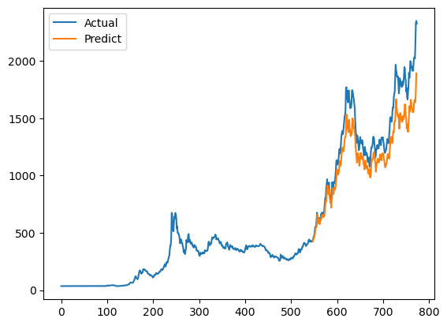

```python
##Plot baseline and predictions
f_data= scaler.inverse_transform(dataset)
train = trainPredictPlot
test = testPredictPlot

# plot baseline and predictions
plt.plot(f_data, label="Actual")
plt.plot(test, label="Predict")
plt.legend()
plt.show()
```

```python
actual_data = pd.DataFrame(f_data)
test_data = pd.DataFrame(testPredictPlot)
df = pd.DataFrame()
df['actual'] = actual_data
df['test'] = test_data
import os
os.getcwd()
df.to_csv("lstm10.csv")
```

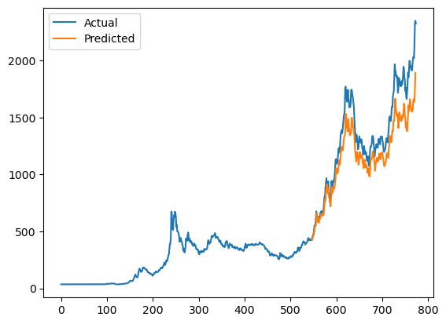

```python
plt.plot(f_data, label="Actual")
plt.plot(test, label="Predicted")
plt.legend()
plt.show()
```